# Processing: IDA WT

Extracellular DNA promotes efficient extracellular electron transfer by pyocyanin in *Pseudomonas aeruginosa* biofilms.

Scott H. Saunders, Edmund C.M. Tse, Matthew D. Yates, Fernanda Jiménez-Otero, Jacqueline K. Barton, Leonard M. Tender and Dianne K. Newman

# Notes

This notebook shows how raw electrochemical data from a CH Instruments potentiostat was processed for data vizualization and downstream analysis.

Setup packages and plotting for the notebook:

```r
# Load packages
library(tidyverse)
library(cowplot)
library(kableExtra)
library(modelr)
library(broom)

# Code display options
knitr::opts_chunk$set(tidy.opts=list(width.cutoff=60),tidy=FALSE, echo = TRUE, message=FALSE, warning=FALSE, fig.align="center", fig.retina = 2)

# Load plotting tools
source("../../tools/plotting_tools.R")

#Modify the plot theme
theme_set(theme_notebook())
```

```r
# Load echem processing tools

source("../../tools/echem_processing_tools.R")
```

## SWV data

First, let’s import all of the SWV files.

```r
# file names and paths
swv_file_paths <-  dir(path='../../../data/Electrochemistry/IDA/WT_biofilm/', pattern = "[swv]+.+[txt]$", recursive = T, full.names = T)

swv_filenames <- basename(swv_file_paths)

# data columns in each file
swv_data_cols <-  c('E','i1','i2')

# metadata in each file name
filename_cols = c('echem','rep')

# skip the header that contains detailed information from the potentiostat
swv_skip_rows=18

# Use the function `echem_import_to_df()` from the echem tools to import
swv_data <- echem_import_to_df(filenames = swv_filenames,
                                       file_paths = swv_file_paths,
                                       data_cols = swv_data_cols,
                                       skip_rows = swv_skip_rows,
                                       filename_cols = filename_cols,
                                       rep = T, PHZadded = F) %>%
  mutate(rep=rep-1)

# Change the rep (acquisition number) for the SWVs because the first SWV should be 0.
# This is used to match SWV and GC by number later on.
# We also add an experimental id of 1.
```

Let’s look at the data frame we have generated:

```r
swv_data %>% head() %>%  kable(digits = 10) %>% kable_styling() %>% scroll_box(height = '300px')
```

| echem | rep | minutes | E | electrode | current |
| --- | --- | --- | --- | --- | --- |
| swv | 0 | 976.6167 | 0.099 | i1 | 7.084e-07 |
| swv | 0 | 976.6167 | 0.098 | i1 | 8.403e-07 |
| swv | 0 | 976.6167 | 0.097 | i1 | 8.398e-07 |
| swv | 0 | 976.6167 | 0.096 | i1 | 8.506e-07 |
| swv | 0 | 976.6167 | 0.095 | i1 | 8.717e-07 |
| swv | 0 | 976.6167 | 0.094 | i1 | 7.924e-07 |

We can now plot all of these data. This plot will show the data from the biofilm as it equilibrated in the transfer reactor.

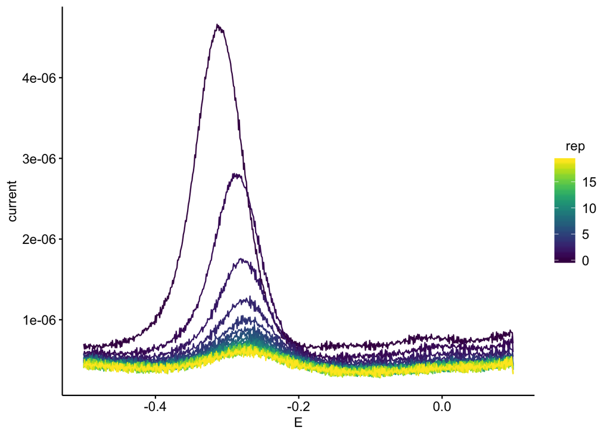

```r
ggplot(swv_data %>% filter(electrode == 'i1'), aes(x = E , y = current )) +
  geom_path(aes(group = rep, color = rep))
```

## GC data

Now, we will repeat the import for the GC data.

```r
gc_file_paths <-  dir(path='../../../data/Electrochemistry/IDA/WT_biofilm/', pattern = "[gc]+.+[txt]$",recursive = T,full.names = T)

gc_filenames <- basename(gc_file_paths)

gc_data_cols <-  c('E','i1','i2')

filename_cols = c('echem','rep')

gc_skip_rows=21


gc_data <- echem_import_to_df(filenames = gc_filenames,
                                       file_paths = gc_file_paths,
                                       data_cols = gc_data_cols,
                                       skip_rows = gc_skip_rows,
                                       filename_cols = filename_cols,
                                       rep = T, PHZadded = F)
```

Here’s the GC data plotted:

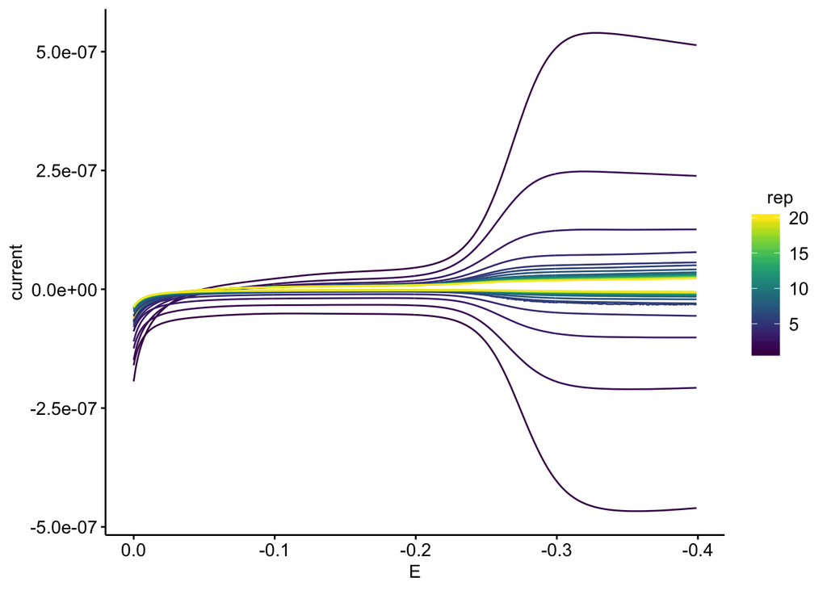

```r
ggplot(gc_data) +
  geom_path(data=. %>% filter(electrode=='i1'), aes(x = E, y = current, color = rep, group = rep)) +
  geom_path(data=. %>% filter(electrode=='i2'), aes(x = E, y = current, color = rep, group = rep)) +
  scale_x_reverse()
```

# Signal quantification

Now that all of the files have been read into convenient data frames we can quantify the peak currents, which are the signals we will use for the analysis later on.

## SWV

To do this we will use another function from the echem tools to find the min and max points within a specified potential window in each scan. Let’s take a look at the output:

```r
# ID columns for function below
unique_id_cols = c('echem','rep','minutes','electrode')

# Use `echem_signal()` from echem tools to find min/max points in each scan
swv_signals <- echem_signal(df = swv_data,
                            unique_id_cols = unique_id_cols,
                            max_interval = c(-0.2,-0.4),
                            min_interval = c(0.0,-0.4))

swv_signals %>% kable(digits = 10) %>% kable_styling() %>% scroll_box(height = '300px')
```

| echem | rep | minutes | E_from_maxs | electrode | current_from_maxs | max_current | E_from_mins | current_from_mins | min_current | signal |
| --- | --- | --- | --- | --- | --- | --- | --- | --- | --- | --- |
| swv | 0 | 976.6167 | -0.314 | i1 | 4.6618e-06 | 4.6618e-06 | -0.100 | 6.197e-07 | 6.197e-07 | 4.0420e-06 |
| swv | 9 | 999.1167 | -0.260 | i1 | 7.5030e-07 | 7.5030e-07 | -0.132 | 3.163e-07 | 3.163e-07 | 4.3400e-07 |
| swv | 10 | 1001.6167 | -0.255 | i1 | 7.3630e-07 | 7.3630e-07 | -0.139 | 3.150e-07 | 3.150e-07 | 4.2130e-07 |
| swv | 11 | 1004.1167 | -0.283 | i1 | 7.1720e-07 | 7.1720e-07 | -0.114 | 3.074e-07 | 3.074e-07 | 4.0980e-07 |
| swv | 12 | 1006.6167 | -0.262 | i1 | 6.9610e-07 | 6.9610e-07 | -0.118 | 2.977e-07 | 2.977e-07 | 3.9840e-07 |
| swv | 13 | 1009.1167 | -0.269 | i1 | 7.1100e-07 | 7.1100e-07 | -0.098 | 2.940e-07 | 2.940e-07 | 4.1690e-07 |
| swv | 14 | 1011.6167 | -0.282 | i1 | 6.9730e-07 | 6.9730e-07 | -0.101 | 2.980e-07 | 2.980e-07 | 3.9930e-07 |
| swv | 15 | 1014.1167 | -0.275 | i1 | 7.0430e-07 | 7.0430e-07 | -0.087 | 2.812e-07 | 2.812e-07 | 4.2310e-07 |
| swv | 16 | 1016.6167 | -0.284 | i1 | 6.8830e-07 | 6.8830e-07 | -0.096 | 2.881e-07 | 2.881e-07 | 4.0020e-07 |
| swv | 17 | 1019.1167 | -0.281 | i1 | 6.7780e-07 | 6.7780e-07 | -0.139 | 2.889e-07 | 2.889e-07 | 3.8900e-07 |
| swv | 18 | 1021.6167 | -0.267 | i1 | 6.8810e-07 | 6.8810e-07 | -0.091 | 2.883e-07 | 2.883e-07 | 3.9980e-07 |
| swv | 1 | 979.1167 | -0.290 | i1 | 2.8127e-06 | 2.8127e-06 | -0.128 | 4.856e-07 | 4.856e-07 | 2.3272e-06 |
| swv | 19 | 1024.1167 | -0.276 | i1 | 6.6910e-07 | 6.6910e-07 | -0.086 | 2.826e-07 | 2.826e-07 | 3.8660e-07 |
| swv | 2 | 981.6167 | -0.281 | i1 | 1.7585e-06 | 1.7585e-06 | -0.139 | 4.282e-07 | 4.282e-07 | 1.3304e-06 |
| swv | 3 | 984.1167 | -0.268 | i1 | 1.2929e-06 | 1.2929e-06 | -0.097 | 3.808e-07 | 3.808e-07 | 9.1200e-07 |
| swv | 4 | 986.6167 | -0.278 | i1 | 1.0515e-06 | 1.0515e-06 | -0.121 | 3.595e-07 | 3.595e-07 | 6.9200e-07 |
| swv | 5 | 989.1167 | -0.262 | i1 | 9.4090e-07 | 9.4090e-07 | -0.122 | 3.476e-07 | 3.476e-07 | 5.9330e-07 |
| swv | 6 | 991.6167 | -0.268 | i1 | 8.8940e-07 | 8.8940e-07 | -0.042 | 3.373e-07 | 3.373e-07 | 5.5200e-07 |
| swv | 7 | 994.1167 | -0.267 | i1 | 8.1970e-07 | 8.1970e-07 | -0.096 | 3.405e-07 | 3.405e-07 | 4.7920e-07 |
| swv | 8 | 996.6167 | -0.257 | i1 | 7.6600e-07 | 7.6600e-07 | -0.081 | 3.210e-07 | 3.210e-07 | 4.4500e-07 |
| swv | 0 | 976.6167 | -0.314 | i2 | 4.2504e-06 | 4.2504e-06 | -0.143 | 4.427e-07 | 4.427e-07 | 3.8077e-06 |
| swv | 9 | 999.1167 | -0.277 | i2 | 6.7760e-07 | 6.7760e-07 | -0.101 | 1.590e-07 | 1.590e-07 | 5.1860e-07 |
| swv | 10 | 1001.6167 | -0.286 | i2 | 6.6530e-07 | 6.6530e-07 | -0.005 | 1.831e-07 | 1.831e-07 | 4.8210e-07 |
| swv | 11 | 1004.1167 | -0.297 | i2 | 6.7400e-07 | 6.7400e-07 | -0.095 | 1.815e-07 | 1.815e-07 | 4.9250e-07 |
| swv | 12 | 1006.6167 | -0.277 | i2 | 6.6480e-07 | 6.6480e-07 | -0.039 | 1.510e-07 | 1.510e-07 | 5.1380e-07 |
| swv | 13 | 1009.1167 | -0.277 | i2 | 6.4880e-07 | 6.4880e-07 | -0.026 | 1.747e-07 | 1.747e-07 | 4.7410e-07 |
| swv | 14 | 1011.6167 | -0.272 | i2 | 6.6290e-07 | 6.6290e-07 | -0.067 | 1.789e-07 | 1.789e-07 | 4.8400e-07 |
| swv | 15 | 1014.1167 | -0.291 | i2 | 6.3890e-07 | 6.3890e-07 | -0.130 | 1.703e-07 | 1.703e-07 | 4.6850e-07 |
| swv | 16 | 1016.6167 | -0.292 | i2 | 6.2290e-07 | 6.2290e-07 | -0.038 | 1.516e-07 | 1.516e-07 | 4.7140e-07 |
| swv | 17 | 1019.1167 | -0.283 | i2 | 6.2390e-07 | 6.2390e-07 | -0.013 | 1.683e-07 | 1.683e-07 | 4.5560e-07 |
| swv | 18 | 1021.6167 | -0.291 | i2 | 6.2480e-07 | 6.2480e-07 | -0.065 | 1.555e-07 | 1.555e-07 | 4.6930e-07 |
| swv | 1 | 979.1167 | -0.285 | i2 | 2.5031e-06 | 2.5031e-06 | -0.059 | 3.078e-07 | 3.078e-07 | 2.1953e-06 |
| swv | 19 | 1024.1167 | -0.304 | i2 | 5.8840e-07 | 5.8840e-07 | -0.062 | 1.411e-07 | 1.411e-07 | 4.4720e-07 |
| swv | 2 | 981.6167 | -0.277 | i2 | 1.5243e-06 | 1.5243e-06 | -0.077 | 2.396e-07 | 2.396e-07 | 1.2847e-06 |
| swv | 3 | 984.1167 | -0.270 | i2 | 1.0867e-06 | 1.0867e-06 | -0.071 | 2.176e-07 | 2.176e-07 | 8.6910e-07 |
| swv | 4 | 986.6167 | -0.275 | i2 | 9.0090e-07 | 9.0090e-07 | -0.049 | 1.991e-07 | 1.991e-07 | 7.0190e-07 |
| swv | 5 | 989.1167 | -0.286 | i2 | 7.9830e-07 | 7.9830e-07 | -0.074 | 2.135e-07 | 2.135e-07 | 5.8480e-07 |
| swv | 6 | 991.6167 | -0.299 | i2 | 7.6350e-07 | 7.6350e-07 | -0.080 | 2.106e-07 | 2.106e-07 | 5.5290e-07 |
| swv | 7 | 994.1167 | -0.303 | i2 | 7.1840e-07 | 7.1840e-07 | -0.079 | 1.772e-07 | 1.772e-07 | 5.4120e-07 |
| swv | 8 | 996.6167 | -0.295 | i2 | 7.2560e-07 | 7.2560e-07 | -0.055 | 1.669e-07 | 1.669e-07 | 5.5870e-07 |

Here we will plot all of the transfer SWV data with the min/max points we found:

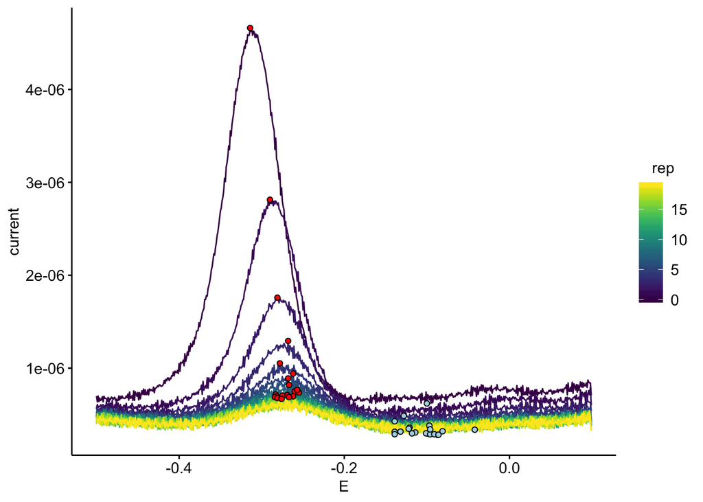

```r
ggplot(swv_data %>% filter(electrode == 'i1'), aes(x = E , y = current )) +
  geom_path(aes(group = rep, color = rep)) +
  geom_point(data = swv_signals %>% filter(electrode == 'i1'), aes(x = E_from_mins, y = current_from_mins), shape = 21, fill = 'light blue') +
  geom_point(data = swv_signals %>% filter(electrode == 'i1'), aes(x = E_from_maxs, y = current_from_maxs), shape = 21, fill = 'red')
```

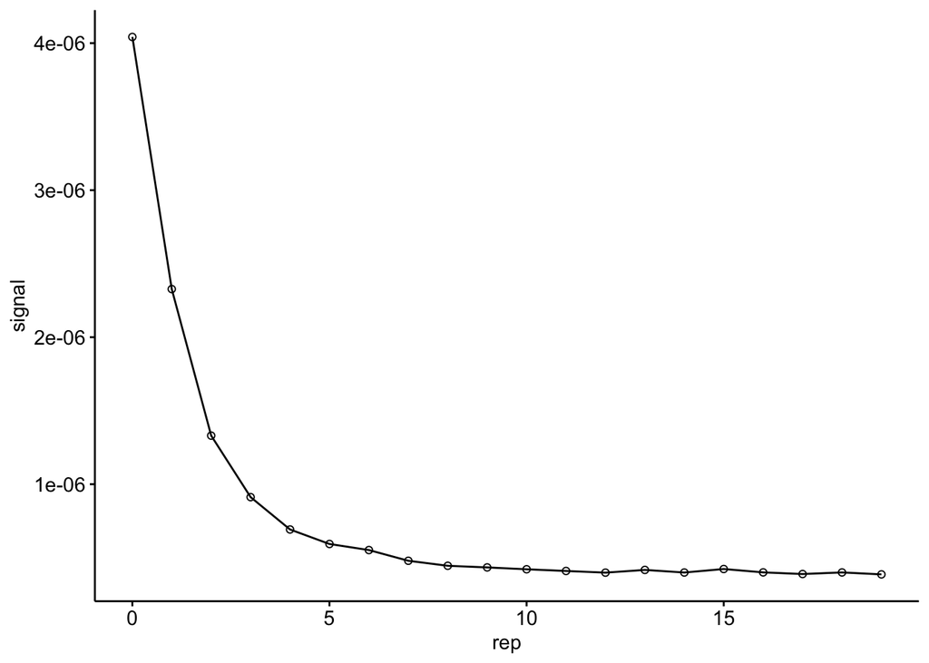

```r
ggplot(data = swv_signals %>% filter(electrode == 'i1'), aes(x = rep, y = signal)) +
  geom_line() +
  geom_point(shape = 21, color = 'black')
```

## GC

Let’s repeat a similar process for the GC data. First we will quantify using `echem_signal()`. For GC data we only take the last point (~ -0.4V), since that point is the closest in time to the following SWV. Later we will pair these datasets, so that’s important.

```r
unique_id_cols = c('echem','rep','minutes','electrode')

gc_signals <- echem_signal(df = gc_data %>% filter(electrode == 'i2') %>% mutate(current = - current),
                            unique_id_cols = unique_id_cols,
                            max_interval = c(-0.399,-0.399),
                            min_interval = c(0.0,-0.4))
```

Now we can plot the GC scans and the min / max points.

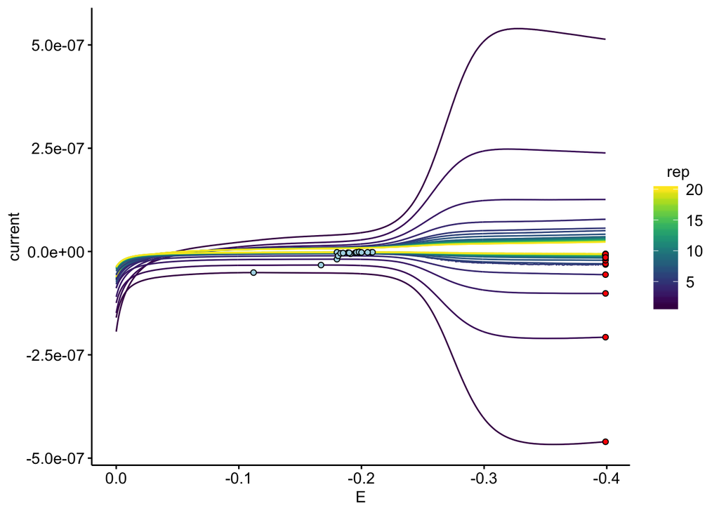

```r
ggplot(gc_data) +
  geom_path(data=. %>% filter(electrode=='i1'), aes(x = E, y = current, color = rep, group = rep)) +
  geom_path(data=. %>% filter(electrode=='i2'), aes(x = E, y = current, color = rep, group = rep)) +
  geom_point(data = gc_signals, aes(x = E_from_mins, y = -current_from_mins), shape = 21, fill = 'light blue')+
  geom_point(data = gc_signals, aes(x = E_from_maxs, y = -current_from_maxs), shape = 21, fill = 'red')+
  scale_x_reverse()
```

Note we always quantify from the negative collector current. Now, let’s look at the background subtracted GC peak currents over time:

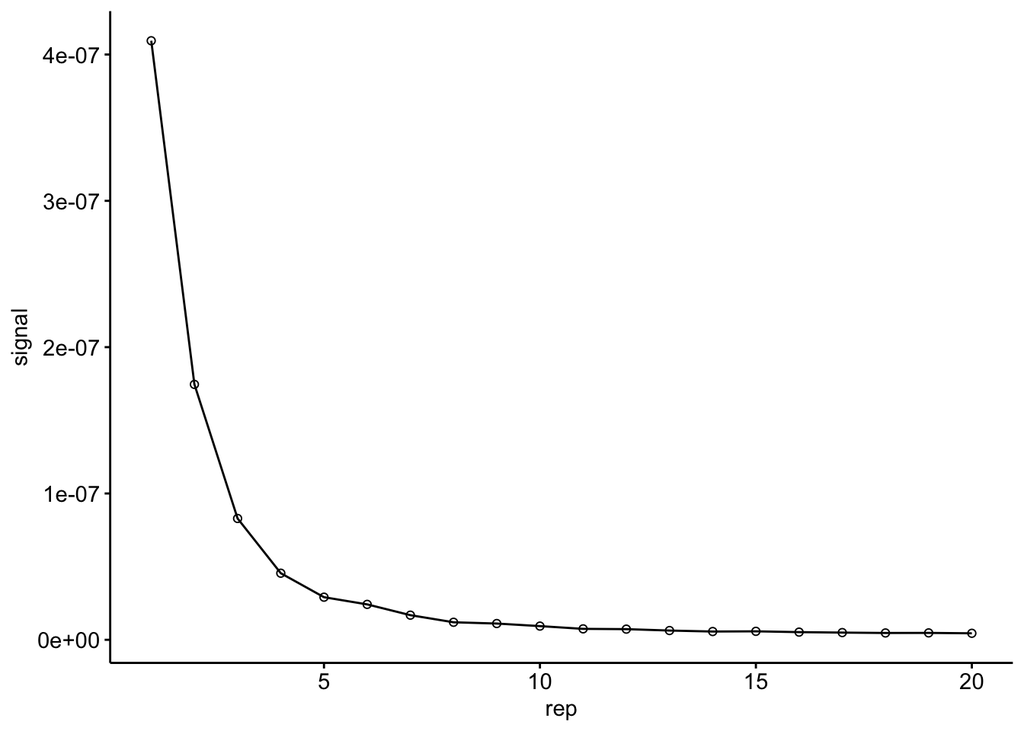

```r
ggplot(data = gc_signals, aes(x = rep, y = signal)) +
  geom_line() +
  geom_point(shape = 21, color = 'black')
```

# Timing and SWV / GC matching

Now we will convert `rep` into an actual time:

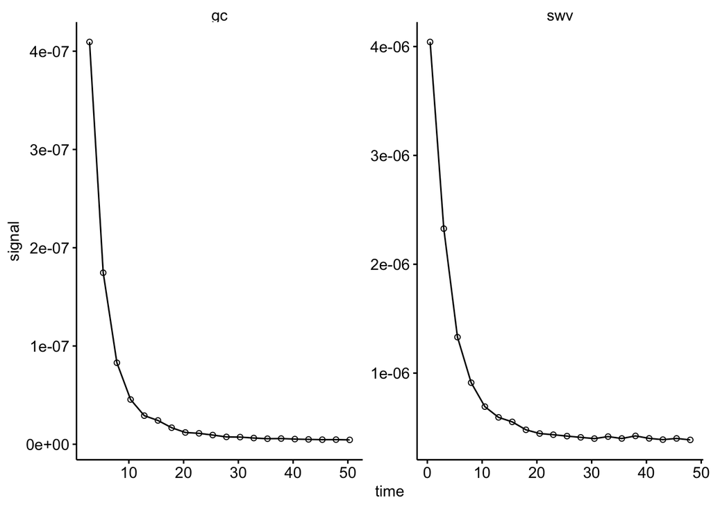

```r
df_signals <- bind_rows(swv_signals %>% filter(electrode == 'i1'), gc_signals) %>%
  group_by() %>%
  mutate(min_time = min(minutes)) %>%
  mutate(time = minutes - min_time + 0.5)

ggplot(data = df_signals, aes(x = time, y = signal)) +
  geom_line() +
  geom_point(shape = 21, color = 'black') + facet_wrap(~echem, scales = 'free')
```

And we will join the SWV and GC by `rep`, allowing us to plot the signals against each other:

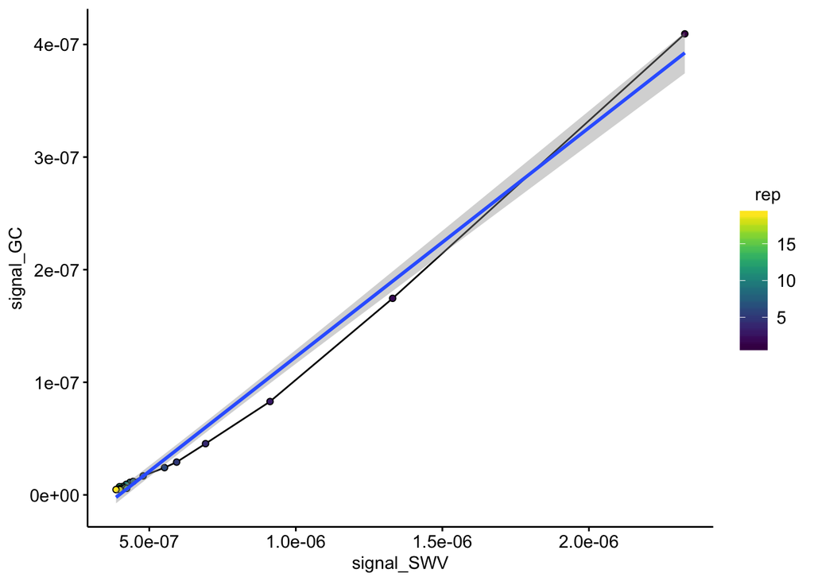

```r
df_swv_gc <- left_join(df_signals %>% filter(echem == 'swv'), df_signals %>% filter(echem == 'gc'),
                       by = c('rep'), suffix = c('_SWV','_GC'))

ggplot(data = df_swv_gc %>% filter(rep >0),
       aes(x = signal_SWV, y = signal_GC, fill = rep)) +
  geom_line() + geom_point(shape = 21, color = 'black') + geom_smooth(method = 'lm')
```

# Output

Let’s write our swv and gc signal dataframes to csv files to be used for further analysis.

```r
write_csv(df_swv_gc, "../processed_data/phz_eDNA_2019_swv_gc_WT_signals.csv")
```